# Pediction of Online Shoppers’ Purchasing Intention

## 3.3 Data Visualization

- Chart 1: created a heat map to see the correlation between 10 numerical variables. We found that the type of page and the stay of that page has relatively higher correlations.

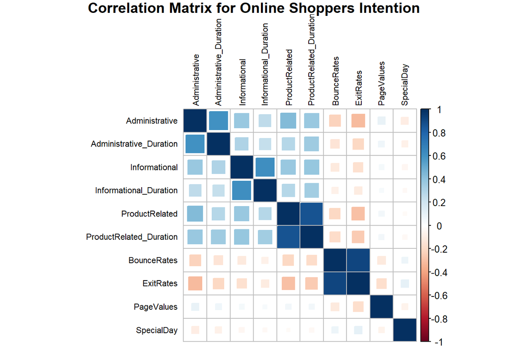

```r
data_vis <- data[,]
col <- cor(data_vis[, c("Administrative","Administrative_Duration", "Informational",  "Informational_Duration", "ProductRelated","ProductRelated_Duration", "BounceRates", "ExitRates", "PageValues", "SpecialDay") ])
corrplot(col, method = "square", title ="Correlation Matrix for Online Shoppers Intention", tl.cex = 0.7, tl.col = "black", mar = c(1,1,1,1))
```

- Chart 2: used pairs.panels to create a correlation, density and hist diagram of two features: ProductRelated and ProductRelated_Duration, which has the second-highest correlation value.

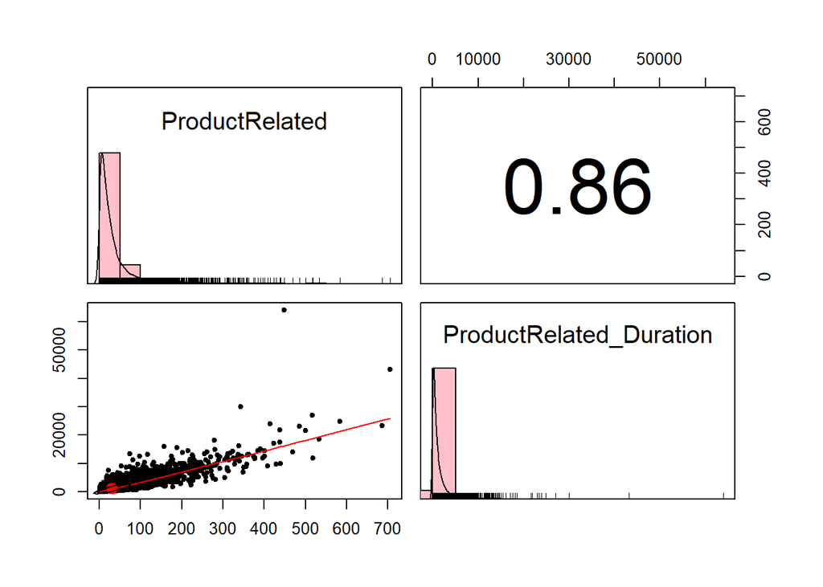

```r
pairs.panels(data_vis[c("ProductRelated","ProductRelated_Duration")],
             method = "pearson", # correlation method
             hist.col = "pink",
             density = TRUE,  # show density plots
             )
```

- Chart 3: used the pairs.panels to display the highest correlation value of BounceRates and ExitRates.

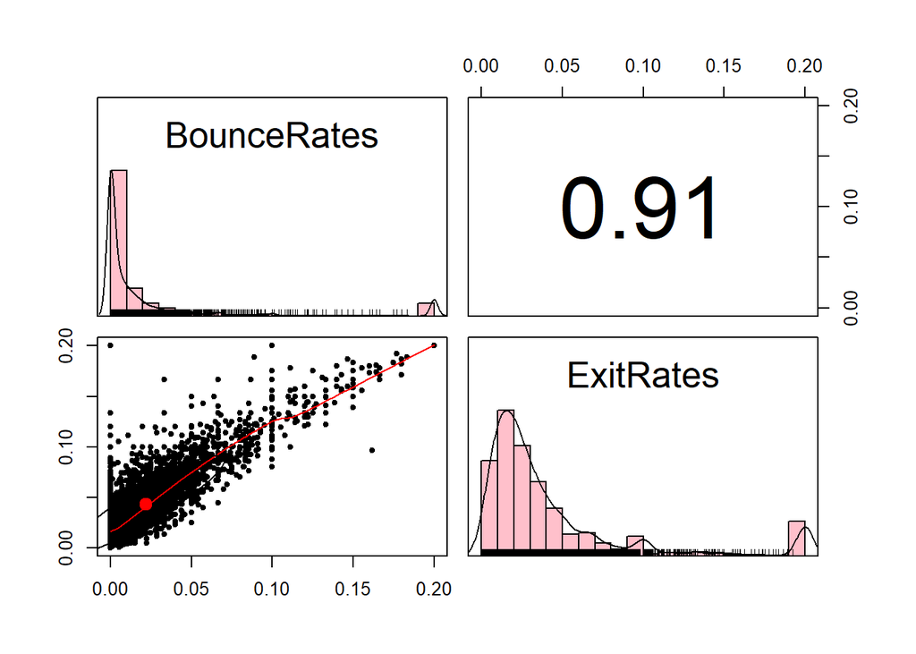

```r
pairs.panels(data_vis[c("BounceRates", "ExitRates")],
             method = "pearson", # correlation method
             hist.col = "pink",
             density = TRUE,  # show density plots
             )
```

- Chart 4: used barplot to display popular shopping months and found out “May” is the most popular one.

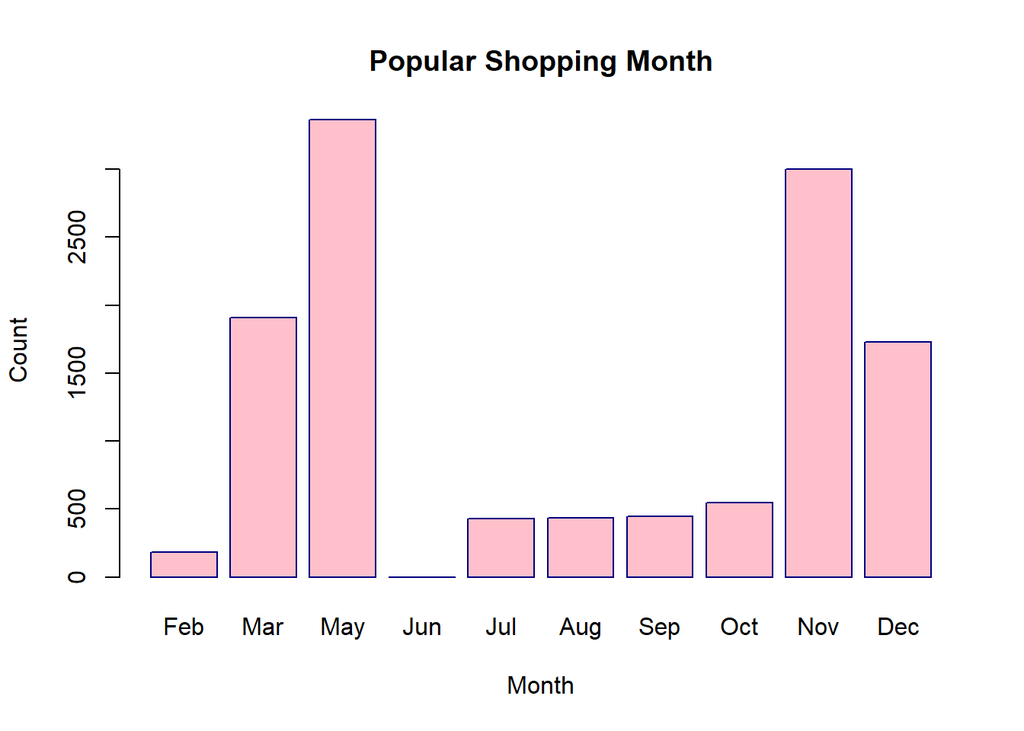

```r
data_vis$Month <-factor(data_vis$Month, levels = c("Feb", "Mar", "May", "Jun", "Jul", "Aug", "Sep", "Oct", "Nov", "Dec"))
barplot(table(data_vis$Month), main="Popular Shopping Month", xlab= "Month", ylab="Count",border="navy",
col="pink")
```

- Chart 5: displayed the different types of visitors and found out “returning_visitor” has many more numbers.

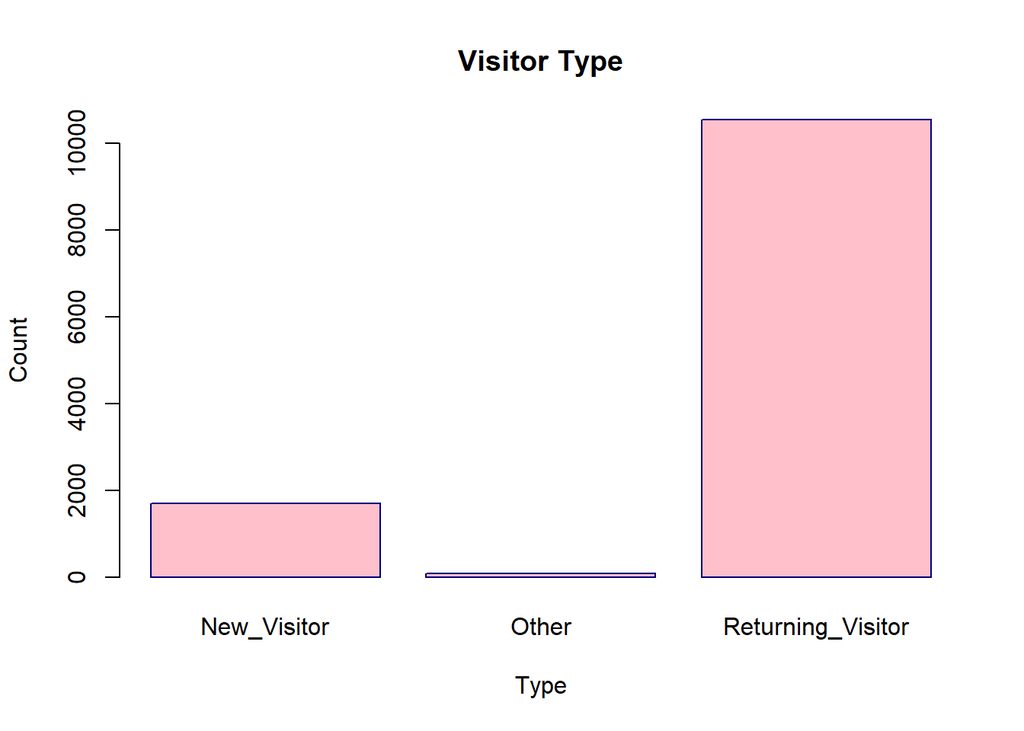

```r
barplot(table(data_vis$VisitorType), main="Visitor Type", xlab= "Type", ylab="Count",border="navy" ,col = "pink")
```

# 4 Model Training without Oversampling

Support vector machine, Random Forest and Multilayer Perceptron models to predict shoppers’ purchasing intention.

- Support Vector Machines (SVM) SVM a very often used for classification. It uses hyperplanes to split the data into separate groups, or classes. And kernel tricks can help with transforming the data to a higher dimension before the hyperplanes split the data into groups.
- Random Forest: Decision trees and Random Forest is very useful for feature selection since there is always a binary split at every node.
- Multilayer perceptron (MLP) is one of the most often used neural_network for classification. Users may specify the number of hidden layers. The model optimize a log-loss function using stochastic gradient descent.

## 4.1 Support Vector Machine

SVM is very often used for classification. It uses hyperplanes to split the data into separate groups, or classes. And kernel tricks can help with transforming the data to a higher dimension before the hyperplanes split the data into groups.

**set categorical features as class variables.**

```r
data$OperatingSystems <- as.factor(data$OperatingSystems)
data$Browser <- as.factor(data$Browser)
data$Region <- as.factor(data$Region)
data$TrafficType <- as.factor(data$TrafficType)
data$VisitorType <- as.factor(data$VisitorType)
data$Weekend <- as.factor(data$Weekend)
data$Month <- as.factor(data$Month)
data$Revenue <- as.factor(data$Revenue)
```

**train test split**

```r
sample_size <- floor(0.9 * nrow(data))
train_ind <- sample(seq_len(nrow(data)), size = sample_size)
data_train <- data[train_ind, ]
data_test <- data[-train_ind, ]
```

```r
svm_model <- ksvm(Revenue ~ ., data = data_train, kernel = "vanilladot")
svm_pred<- predict(svm_model, data_test)
F1_Score(y_pred = svm_pred, y_true = data_test$Revenue, positive = "TRUE")
```

```
## [1] 0.5088339
```

```r
Accuracy(y_pred = svm_pred, y_true = data_test$Revenue)
```

```
## [1] 0.8872668
```

## 4.2 Random forest

```r
require(randomForest)
rf_model<- randomForest(Revenue~., data=data_train,importance=TRUE,ntree=15)
rf_pred <- predict(rf_model, data_test)
F1_Score(y_pred = rf_pred, y_true = data_test$Revenue, positive = "TRUE")
```

```
## [1] 0.626087
```

```r
Accuracy(y_pred = rf_pred, y_true = data_test$Revenue)
```

```
## [1] 0.8953771
```

## 4.3 Multilayer Perceptron Classifier

```r
data_numeric <- data[,]
data_numeric$Revenue <- as.integer(as.factor(data_numeric$Revenue))
data_numeric$Month <- as.integer(as.factor(data_numeric$Month))
data_numeric$Weekend <- as.integer(as.factor(data_numeric$Weekend))
data_numeric$VisitorType <- as.integer(as.factor(data_numeric$VisitorType))
data_numeric$TrafficType <- as.integer(as.factor(data_numeric$TrafficType))
data_numeric$Region <- as.integer(as.factor(data_numeric$Region))
data_numeric$Browser <- as.integer(as.factor(data_numeric$Browser))
data_numeric$OperatingSystems <- as.integer(as.factor(data_numeric$OperatingSystems))
```

```r
data_numeric_train <- data_numeric[train_ind, ]
data_numeric_test <- data_numeric[-train_ind, ]
```

```r
mlp_train <- data_numeric_train[sample(1:nrow(data_numeric_train),length(1:nrow(data_numeric_train))),1:ncol(data_numeric_train)]

mlp_train_x <- mlp_train[,1:17]
mlp_train_y <- decodeClassLabels(mlp_train[,18])
mlp_data <- splitForTrainingAndTest(mlp_train_x, mlp_train_y, ratio=0.1)

mlp_model <- mlp(mlp_data$inputsTrain, mlp_data$targetsTrain, size=50, learnFuncParams=c(0.001),
             linOut=FALSE,hiddenActFunc = "Act_Logistic",
              maxit=50, inputsTest=mlp_data$inputsTest, targetsTest=mlp_data$targetsTest)
```

```r
mlp_test_x <- data_numeric_test[,1:17]
mlp_test_y <- decodeClassLabels(data_numeric_test[,18])
mlp_pred <- predict(mlp_model,mlp_test_x, type="class")
```

```r
gold = as.numeric(mlp_test_y[,2])
temp <- as.numeric(mlp_pred[,2])
pred <- temp

pred[temp>0.2] = 1
pred[temp<=0.2] = 0


tp = 0
fp = 0
fn = 0
tn = 0

for (i in 1:1233){

  if(gold[i]==1){
    if(pred[i]==1){
      tp = tp + 1
    }
    else{
      fn = fn + 1
    }
  }
  else{
    if(pred[i]==1){
     fp  = fp + 1
    }
    else{
      tn  = tn + 1
    }
  }
}

recall = tp/(tp+fn)
preci = tp/(tp+fp)
f1 = 2*recall*preci/(recall + preci)
accuracy = (tp+tn)/(tp+tn+fp+fn)
print(f1)
```

```
## [1] 0.1538462
```

```r
print(accuracy)
```

```
## [1] 0.8572587
```

# 5 Model Training with Oversampling

Because the data set is highly imbalances such that there are far fewer users who made the purchases than those who did not, we used oversampling to increase the number of purchased users, by simply duplicating the entries 5.5 times. After this process, the categories for users who made the final purchases and who did not contain the same number of entries.

**Oversampling**

```r
data_over <- read.csv("online_shoppers_intention.csv")
data_over <- na.locf(data_over)
data_over$OperatingSystems <- as.factor(data_over$OperatingSystems)
data_over$Browser <- as.factor(data_over$Browser)
data_over$Region <- as.factor(data_over$Region)
data_over$TrafficType <- as.factor(data_over$TrafficType)
data_over$VisitorType <- as.factor(data_over$VisitorType)
data_over$Weekend <- as.factor(data_over$Weekend)
data_over$Month <- as.factor(data_over$Month)
data_over$Revenue <- as.factor(data_over$Revenue)
```

```r
data_over_train <- data_over[train_ind, ]
data_over_test <- data_over[-train_ind, ]
data_over_train <- upSample(data_over_train, data_over_train$Revenue)
data_over_train <- select(data_over_train, -Class)
```

## 5.1 Support Vector Machines (SVMs)

```r
svm_over <- ksvm(Revenue ~ ., data = data_over_train, kernel = "vanilladot")
svm_over_pred<- predict(svm_over, data_over_test)
F1_Score(y_pred = svm_over_pred, y_true = data_over_test$Revenue, positive = "TRUE")
```

```
## [1] 0.6285714
```

```r
Accuracy(y_pred = svm_over_pred, y_true = data_over_test$Revenue)
```

```
## [1] 0.8734793
```

## 5.2 RandomForest

```r
require(randomForest)
rf_over <- randomForest(Revenue~., data=data_over_train,importance=TRUE,ntree=15)
rf_over_pred<- predict(rf_over,data_over_test)
F1_Score(y_pred = rf_over_pred, y_true = data_over_test$Revenue, positive = "TRUE")
```

```
## [1] 0.6368421
```

```r
Accuracy(y_pred = rf_over_pred, y_true = data_over_test$Revenue)
```

```
## [1] 0.8880779
```

## 5.3 Multilayer Perceptron Classifier

```r
data_over_numeric <- data_over[,]
data_over_numeric$Revenue <- as.factor(data_over_numeric$Revenue)
data_over_numeric$Month <- as.integer(as.factor(data_over_numeric$Month))
data_over_numeric$Weekend <- as.integer(as.factor(data_over_numeric$Weekend))
data_over_numeric$VisitorType <- as.integer(as.factor(data_over_numeric$VisitorType))
data_over_numeric$TrafficType <- as.integer(as.factor(data_over_numeric$TrafficType))
data_over_numeric$Region <- as.integer(as.factor(data_over_numeric$Region))
data_over_numeric$Browser <- as.integer(as.factor(data_over_numeric$Browser))
data_over_numeric$OperatingSystems <- as.integer(as.factor(data_over_numeric$OperatingSystems))
```

```r
data_over_numeric_train <- data_over_numeric[train_ind, ]
data_over_numeric_test <- data_over_numeric[-train_ind, ]
```

```r
mlp_over_train_raw_order <- data_over_numeric_train
mlp_over_train <- data_over_numeric_train[sample(1:nrow(data_over_numeric_train),length(1:nrow(data_over_numeric_train))),1:ncol(data_over_numeric_train)]

mlp_over_train_x <- mlp_over_train[,1:17]
mlp_over_train_y <- decodeClassLabels(mlp_over_train[,18])

mlp_over_data <- splitForTrainingAndTest(mlp_over_train_x, mlp_over_train_y, ratio=0.1)
# iris <- normTrainingAndTestSet(iris)

mlp_over <- mlp(mlp_over_data$inputsTrain, mlp_over_data$targetsTrain, size=20, learnFuncParams=c(0.001),
              maxit=150, learnFunc="Rprop", inputsTest=mlp_over_data$inputsTest, targetsTest=mlp_over_data$targetsTest)
```

```r
mlp_over_test_x <- data_over_numeric_test[,1:17]
mlp_over_test_y <- decodeClassLabels(data_over_numeric_test[,18])
mlp_over_pred <- predict(mlp_over,mlp_over_test_x, type="class")
```

```r
gold = as.numeric(mlp_over_test_y[,2])
temp <- as.numeric(mlp_over_pred[,2])
pred <- temp

pred[temp>0.5] = 1
pred[temp<=0.5] = 0


tp = 0
fp = 0
fn = 0
tn = 0

for (i in 1:1233){

  if(gold[i]==1){
    if(pred[i]==1){
      tp = tp + 1
    }
    else{
      fn = fn + 1
    }
  }
  else{
    if(pred[i]==1){
     fp  = fp + 1
    }
    else{
      tn  = tn + 1
    }
  }
}

recall = tp/(tp+fn)
preci = tp/(tp+fp)
f1 = 2*recall*preci/(recall + preci)
accuracy = (tp+tn)/(tp+tn+fp+fn)
print(f1)
```

```
## [1] 0.6167665
```

```r
print(accuracy)
```

```
## [1] 0.8961882
```

## 5.4 Ensemble

Ensemble is to use the predictions of several different models as feature inputs, and train a new model based on these predictions. Theoretically the ensemble modle should be better than the previous models.In our case, this is an ensemble for the SVM, Random Forest, and MLP model with oversampling.

```r
mlp_over_train_x <- mlp_over_train_raw_order[,1:17]
mlp_over_train_y <- decodeClassLabels(mlp_over_train_raw_order[,18])

mlp_over_pred_train <- predict(mlp_over,mlp_over_train_x, type="class")
temp <- as.numeric(mlp_over_pred_train[,2])
mlp_over_pred_train_class <- temp
mlp_over_pred_train_class[temp>0.5] = 1
mlp_over_pred_train_class[temp<=0.5] = 0

mlp_over_pred_test <- predict(mlp_over,mlp_over_test_x, type="class")
temp <- as.numeric(mlp_over_pred_test[,2])
mlp_over_pred_test_class <- temp
mlp_over_pred_test_class[temp>0.5] = 1
mlp_over_pred_test_class[temp<=0.5] = 0

mlp_over_pred_train_class = mlp_over_pred_train_class==TRUE
mlp_over_pred_test_class = mlp_over_pred_test_class==TRUE
mlp_over_pred_train_class = as.factor(mlp_over_pred_train_class)
mlp_over_pred_test_class = as.factor(mlp_over_pred_test_class)
```

```r
rf_pred_train <- predict(rf_over, data_over_train)
svm_pred_train <- predict(svm_over, data_over_train)
ensemble_train <- cbind(svm_pred_train, rf_pred_train, mlp_over_pred_train_class, data_over_train$Revenue)
ensemble_train <- as.data.frame(ensemble_train)
colnames(ensemble_train) <- c("svm", "rf", "mlp", "true")


rf_pred_test <- predict(rf_over, data_over_test)
svm_pred_test <- predict(svm_over, data_over_test)
ensemble_test <- cbind(svm_pred_test, rf_pred_test, mlp_over_pred_test_class, data_over_test$Revenue)
ensemble_test <- as.data.frame(ensemble_test)
colnames(ensemble_test) <- c("svm", "rf", "mlp", "true")
```

```r
ensemble <- randomForest(x=ensemble_train, y= data_over_train$Revenue,importance=TRUE,ntree=3)
#ensemble <- ksvm(x=ensemble_train, y= data_over_train$Revenue, kernel = "vanilladot")
ensemble_pred <- predict(ensemble, ensemble_test)

F1_Score(y_pred = ensemble_pred, y_true = data_over_test$Revenue, positive = "TRUE")
```

```
## [1] 0.7986799
```

```r
Accuracy(y_pred = ensemble_pred, y_true = data_over_test$Revenue)
```

```
## [1] 0.9505272
```

# 6 Feature Selection

Random Forest (without oversamping) will be used for feature selection, trying to identify what features would influence the prediction of shoppers buying intention.

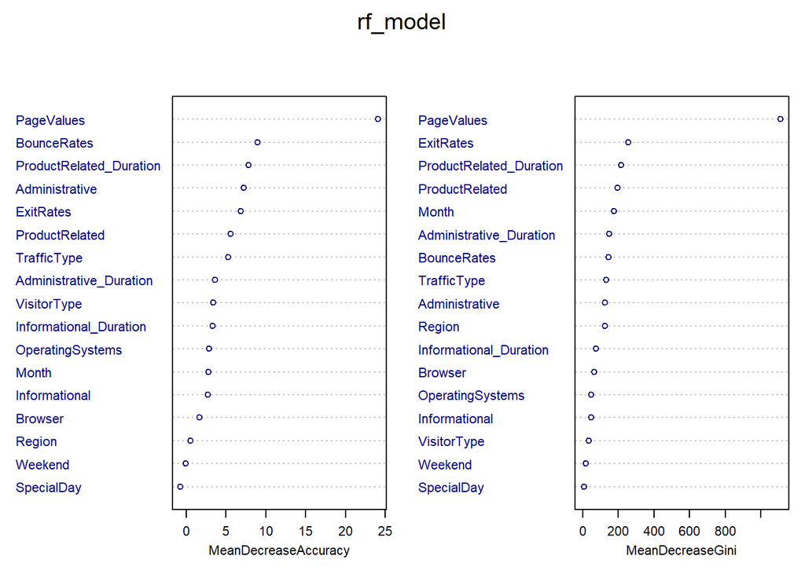

```
##
## Call:
##  randomForest(formula = Revenue ~ ., data = data_train, importance = TRUE,      ntree = 15)
##                Type of random forest: classification
##                      Number of trees: 15
## No. of variables tried at each split: 4
##
##         OOB estimate of  error rate: 11.32%
## Confusion matrix:
##       FALSE TRUE class.error
## FALSE  8860  496  0.05301411
## TRUE    758  966  0.43967517
```

```r
varImpPlot(rf_model, cex=0.7, col="navy"); print(rf_model)
```

In feature selection, Gini index is refering to information gain. According Accuracy and Gini index in the Random Forest model(without oversampling), when PageValues is excluded, both of the metrics would decrease.PageVlues is by far the most important feature when prediction if a viewer will make a final purchase.

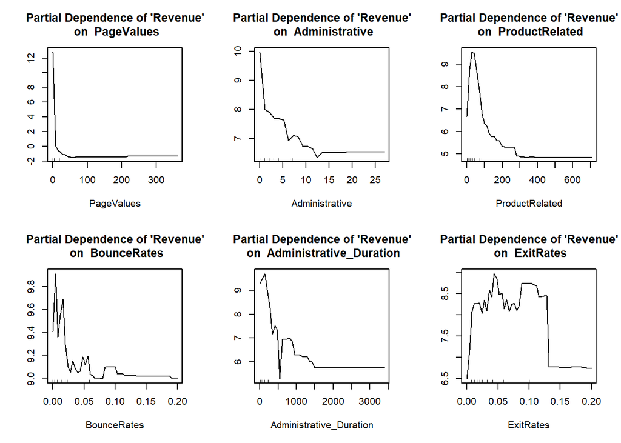

```r
imp <- randomForest::importance(rf_model)
impvar <- rownames(imp)[order(imp[, 1], decreasing=TRUE)]
op <- par(mfrow=c(2, 3))
for (i in 1:6) {   # seq_along(impvar)) { # to plot the marginal probabilities for all features
    partialPlot(rf_model, data_train, impvar[i], xlab=impvar[i],
                main=paste("Partial Dependence of 'Revenue'\n on ", impvar[i]))
}
```

According to the parcial dependecy plots,some most important features are PageValues, ProductRelated, Administrative_Duration. PageValues have an earliest and steepest drop.

According to the common features yiled by the feature selection methods, we could possible stipulate that the value of pages, and number of pages that the viewer go through, and the time that the viewer spends on the related pages will be some crucial features to predict if they will make the final purchase or not. Further statistic analysis is needed to test such hypothese.

# 7 Result

## 7.1 Model prediction

- Model training without oversampling at the first round, Random Forest has comparatively higher accuracy and F1 Score than RF and MLP. After introducing oversampling, they have similar accuracy and F1 Score.
- Oversampling does help with improving the performance of the models.
- The Ensemble using the prediction of the three models yield the best accuracy and f1 score among all.

## 7.2 Feature selection

- Salient features are: Page Value; Product Related (number of related pages have viewed); Product Related Duration(total time spent on related pages).
- We can hypothesize that more attractive the pages are, the more pages the viewer reads, the more time the viewer spends on the pages, the more likely they are going to make a purchase.

# 8 Discussion/Future Research

There are possible bugs for calculating f1 scores running MLP without oversampling. Also, More research for a proper model should be conducted. The three models that are run here may not be the best option for the task. Also, more research for semble should be done in order to show the advantage of the ensemble mode running accurately.

For future research, different methods of data augmentation should be experimented to improve model performance. Statistic analysis of the selected features can be conduct to the causal effect of the purchasing intention. More Parameter tuning should be done to improve the performance of the models. Also, we can experiment with different structures of CNN for better performance.

# 9 Acknowledgment

- Thanks Dr. Dinov for all the great instruction this semester.
- Thanks Xinyan Zhao for his great patience helping with debugging and things for oversampling.

# 10 Reference

Dinov, Ivo D. (2018). Data Science and Predictive Analytics Biomedical and Health Applications using R /. Cham : Springer International Publishing : Imprint: Springer.

Sakar, C Okan, Sakar, C Okan, Polat, S Olcay, Polat, S Olcay, Katircioglu, Mete, Katircioglu, Mete, Kastro, Yomi, et al. (2019). Real-time prediction of online shoppers’ purchasing intention using multilayer perceptron and LSTM recurrent neural networks. Neural Computing and Applications, 31(10), 6893–6908. London: Springer London.

Back to Homepage